# Music genre feature analysis

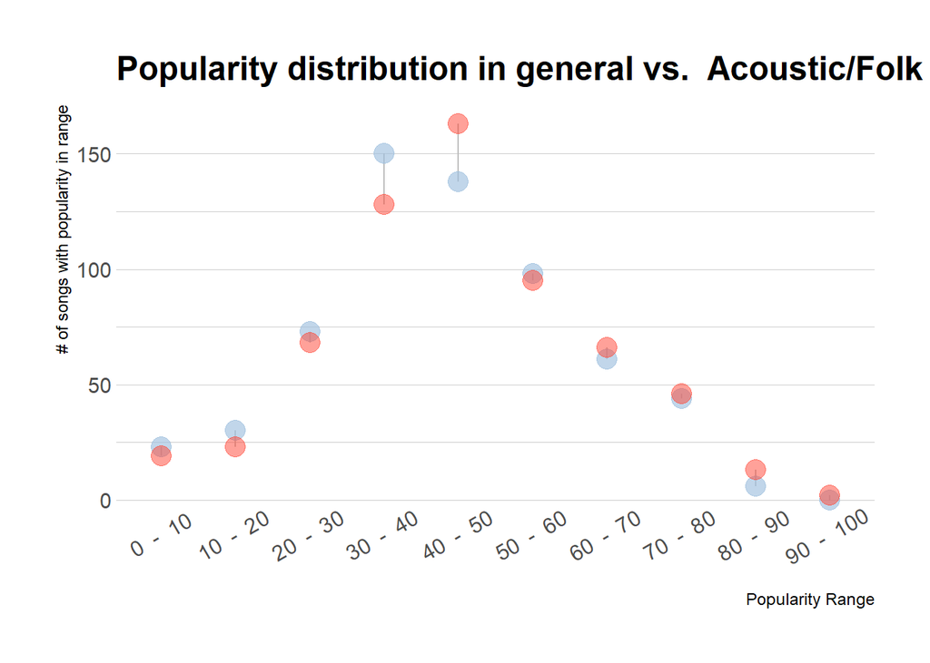

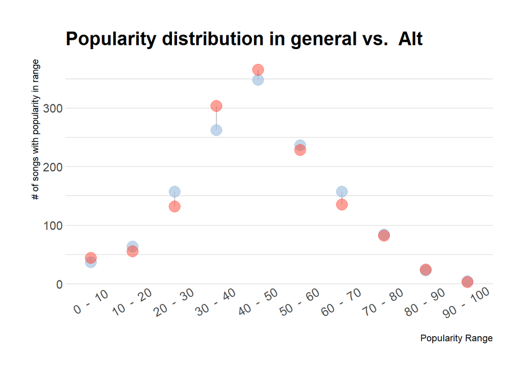

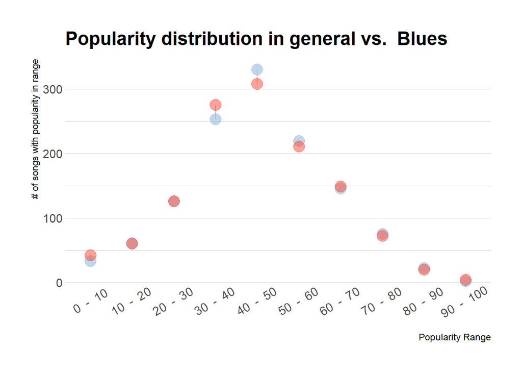

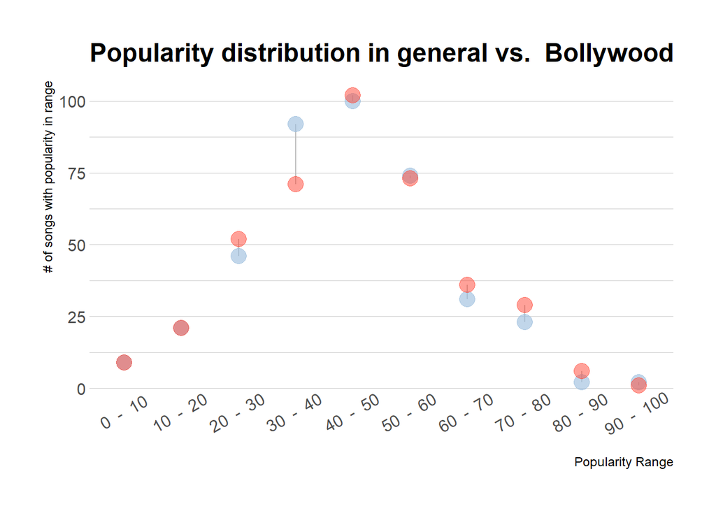

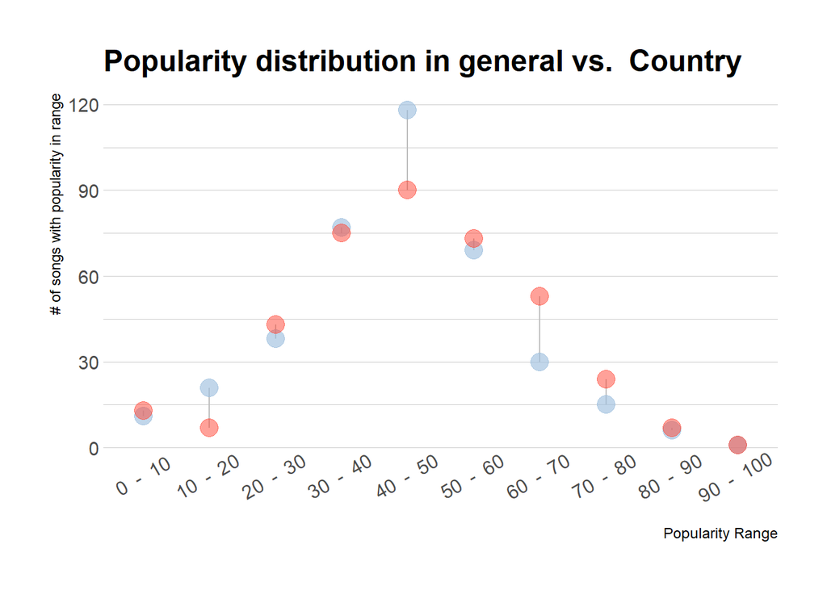

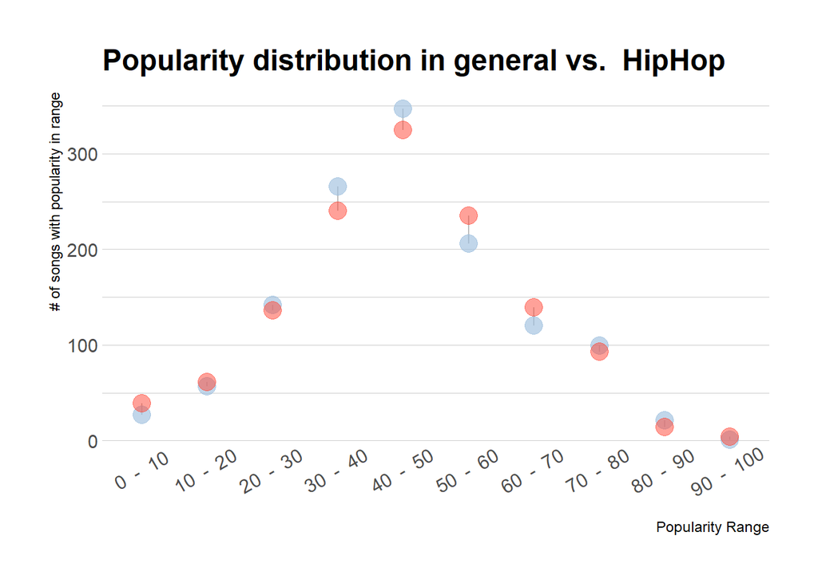

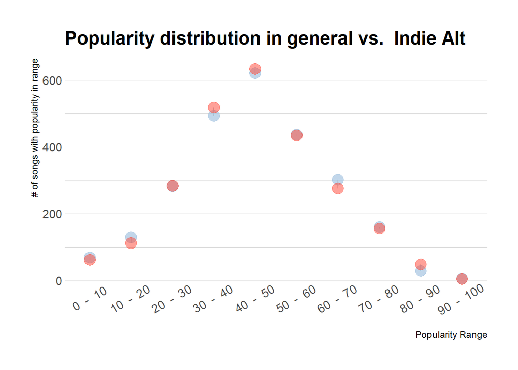

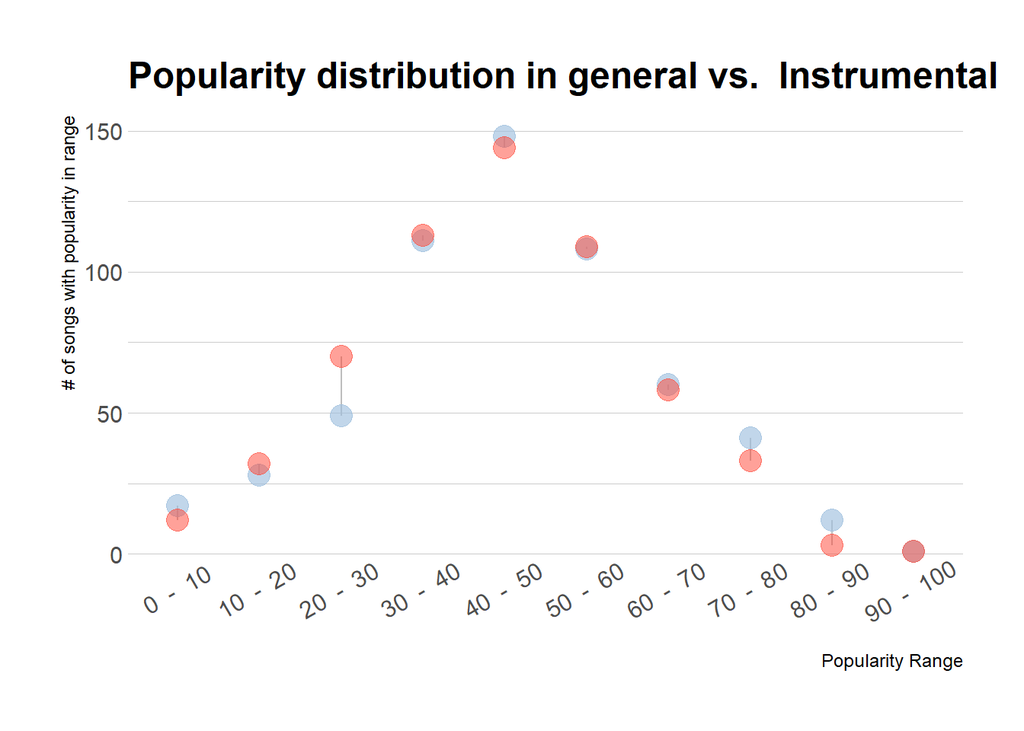

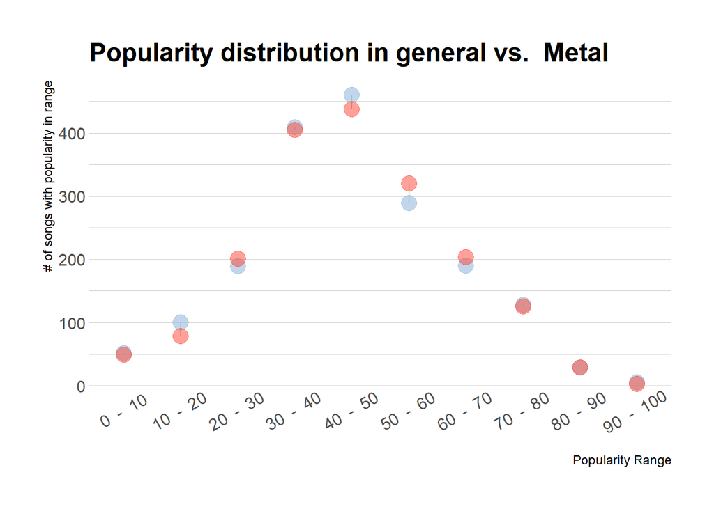

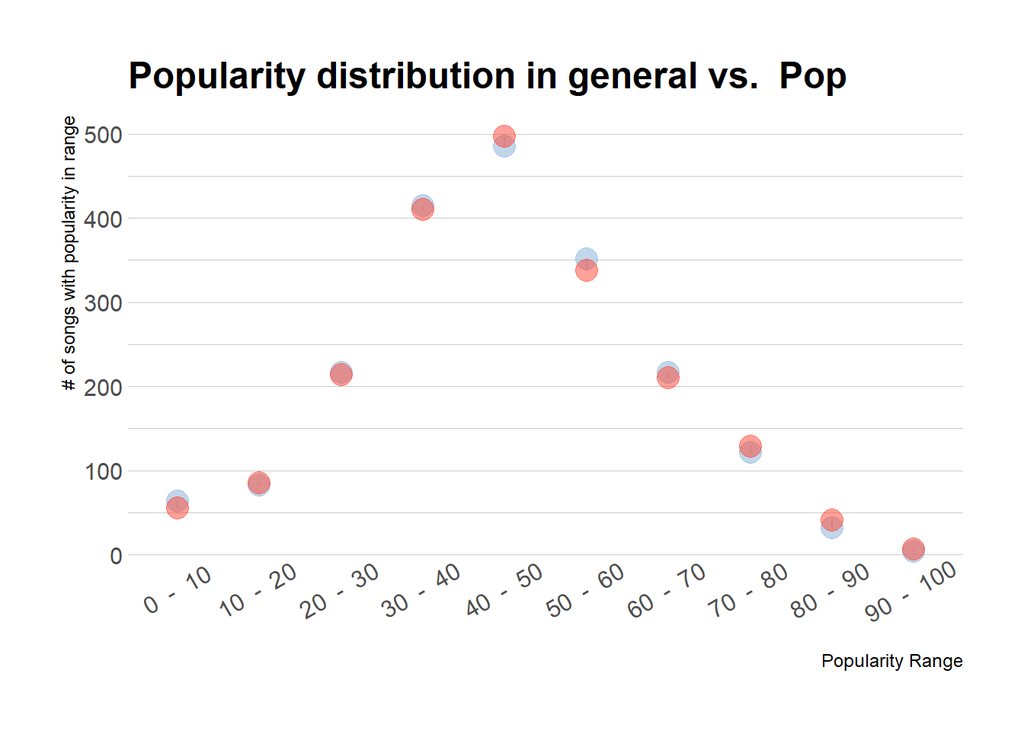

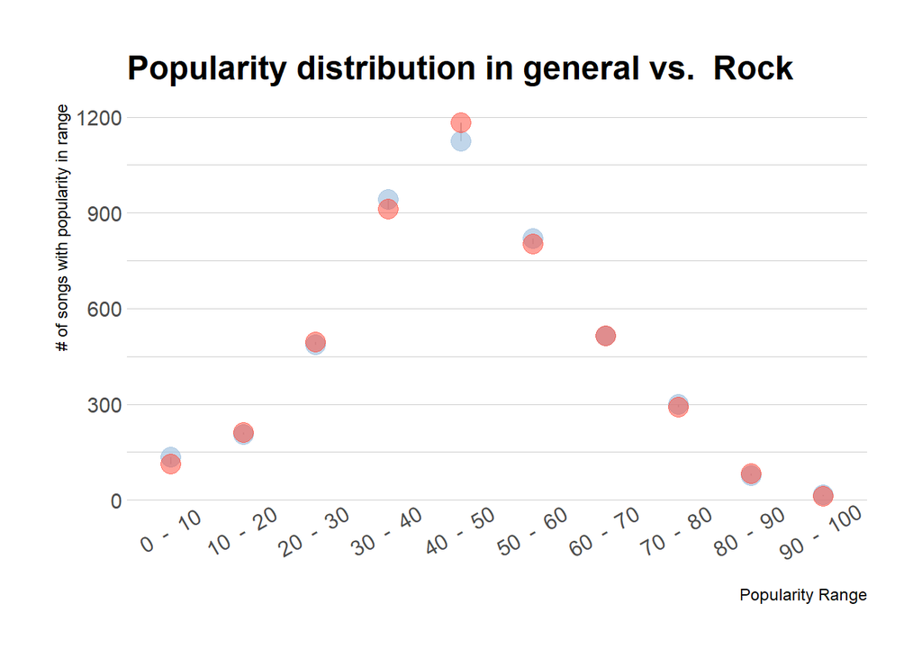

```r
df_bins <- df
df_bins$bins <- bins
df_bins %>% group_by(Genre) %>% group_map(~lolipop_plot_2groups(.x, .y))
```

## 5. Visualizing music features of popular songs in genres

It seems like the genre popularity distributions are pretty close to the general popularity distributions. One question is: does popular songs has a different music feature distribution than others? We can level up the single polygon radar chart we constructed earlier and overlay two polygons in one chart, one for popular song stats and another one for general song stats.

Here, we first include popularity in `feature_names` so that we get that column when subsetting the data.

```r
feature_names <- append(feature_names, "Popularity")
feature_names
```

```
## [1] "instrumentalness" "danceability"     "energy"           "speechiness"
## [5] "acousticness"     "liveness"         "valence"          "Popularity"
```

To follow coding best practices, we remove the part that build the dataframe to feed into radar chart from the plotting function and create a function of its own. We use the median measure for now. Because popular songs might have more extreme skewness/max/min, it might be worthwhile to try those too later.

```r
build_data_tb <- function(tb, popularity_threshold){
  tb_sub <- tb[,feature_names]
  tb_filtered <- filter(tb_sub, Popularity >= popularity_threshold)
  medians_filtered <- c()
  medians_sub <- c()

  feature_names_wo_popularity <- feature_names[1:7]
  for (i in 1:length(feature_names_wo_popularity)){
    filtered_col_numeric <- as.numeric(as.character(unlist(tb_filtered[,feature_names[i]])))
    medians_filtered[i] <- median(filtered_col_numeric)
    sub_col_numeric <- as.numeric(as.character(unlist(tb_sub[,feature_names[i]])))
    medians_sub[i] <- median(sub_col_numeric)
  }
  range_max <- rep(1, length(feature_names_wo_popularity))
  range_min <- rep(0, length(feature_names_wo_popularity))

  data_tb <- data.frame(matrix(ncol = length(feature_names_wo_popularity), nrow = 0))
  data_tb[1,] <- medians_filtered
  data_tb[2,] <- medians_sub

  colnames(data_tb) <- feature_names_wo_popularity
  rownames(data_tb) <- c("popualar songs", "all songs")

  data_tb <- rbind(range_max , range_min , data_tb)

  return(data_tb)
}
```

We set a threshold for popular songs, and plot the data. The `scales` library allow us to set transparency for color without needing the `alpha` argument to be prebuild into the `radarchart` function.

```r
popularity_threshold <- 80

radar_plot_tb_popular <- function(tb, group_by_column){
  tb_genre <- group_by_column$Genre

  data_tb <- build_data_tb(tb, popularity_threshold)

  colors_border=c( scales::alpha("#FF6A4C", 0.6), scales::alpha("#779ecc", 0.5) )
  colors_in=c( scales::alpha("#F99244", 0.6), scales::alpha("#9fc0de", 0.5) )

  radarchart( data_tb    , axistype=0,
    #custom polygon
    pcol=colors_border, pfcol=colors_in , plwd=2 , plty=1,
    #custom the grid
    cglcol="grey", cglty=1, axislabcol="black", cglwd=0.8, caxislabels=seq(0,1,0.1),
    #custom labels
    vlcex=0.8, title=tb_genre
    )
}
```

After plotting this, it seems like the popular songs still have relatively the same features as their genre. Let’s replace measuring using median with using different quantiles, to capture the more extreme cases in the popular songs subset.

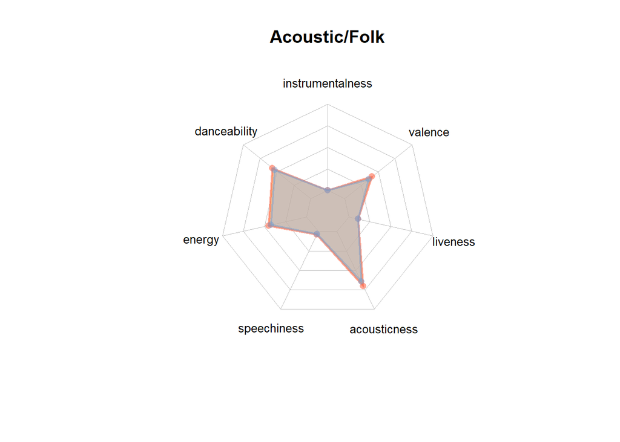

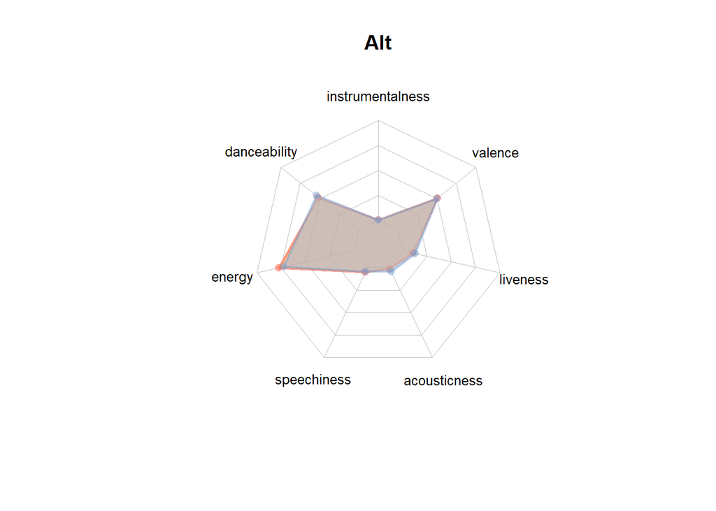

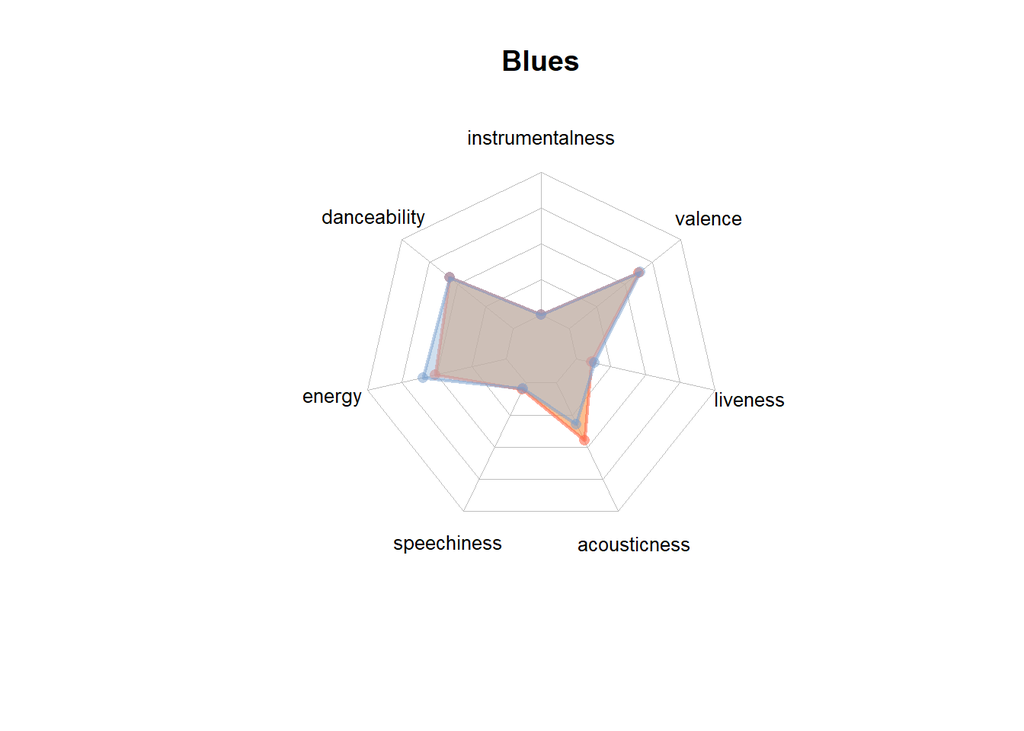

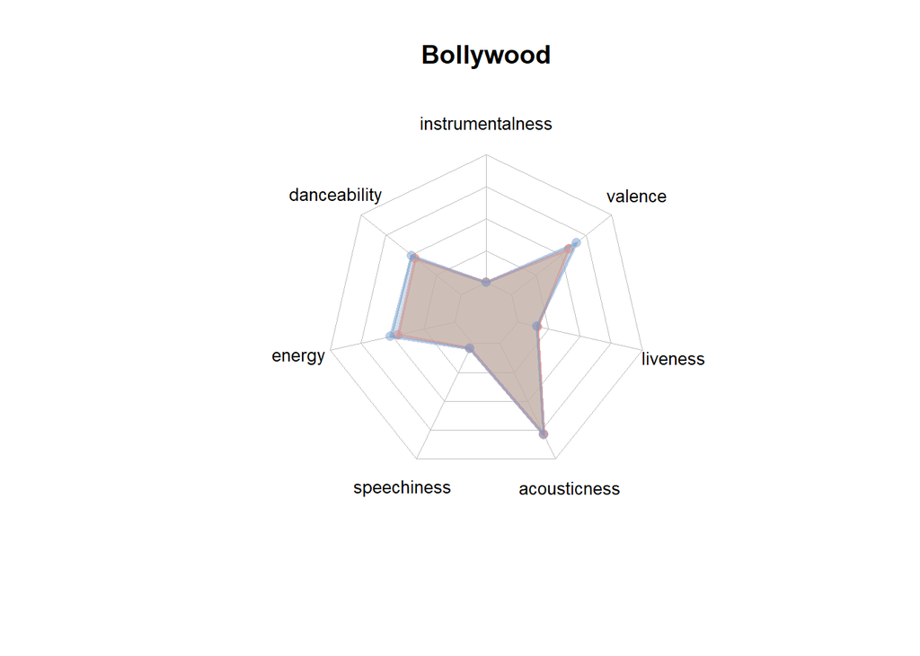

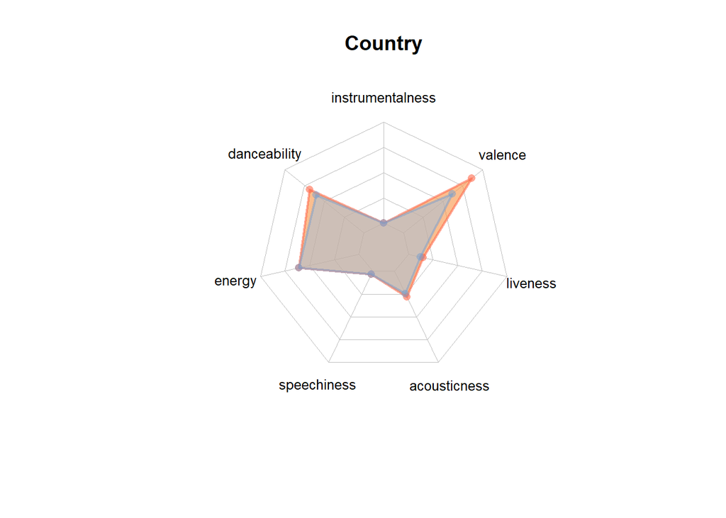

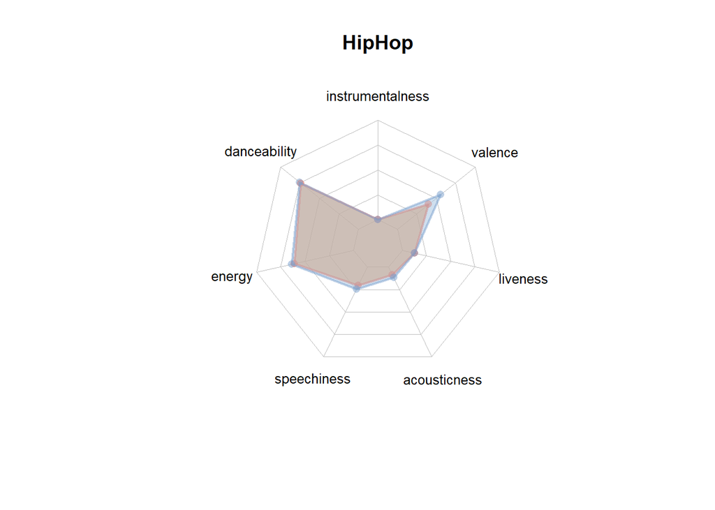

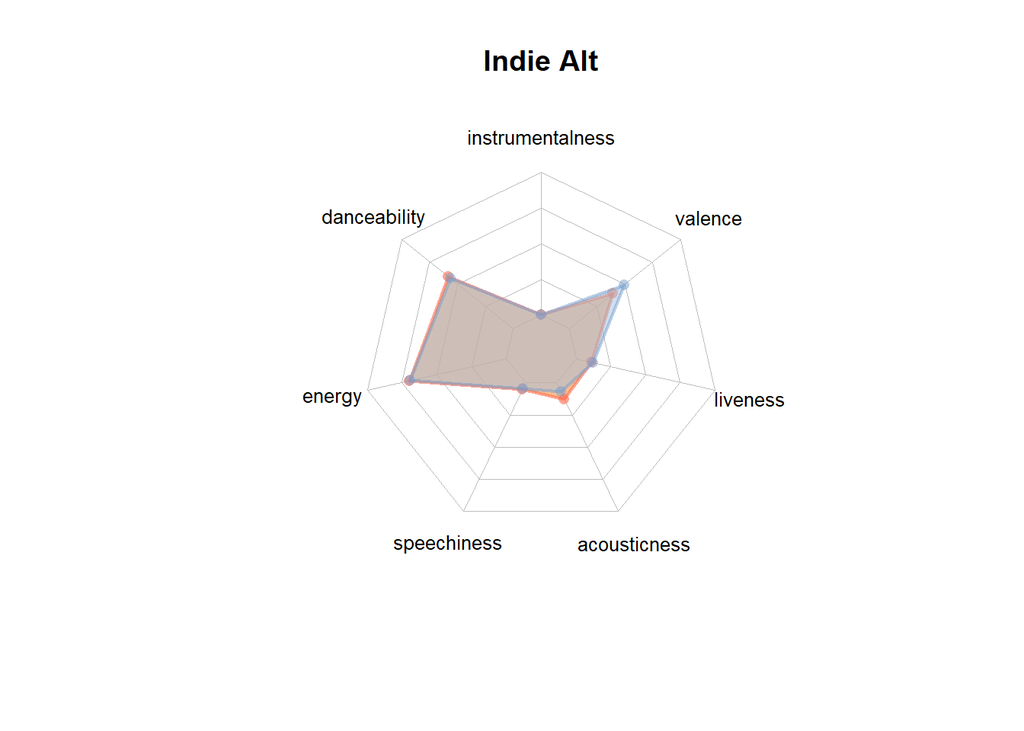

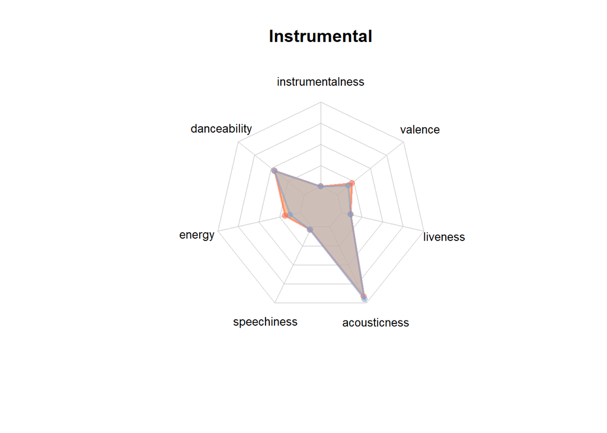

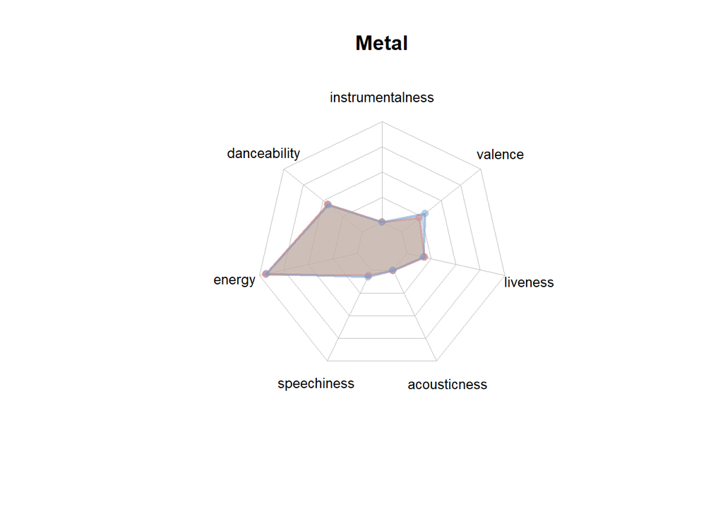

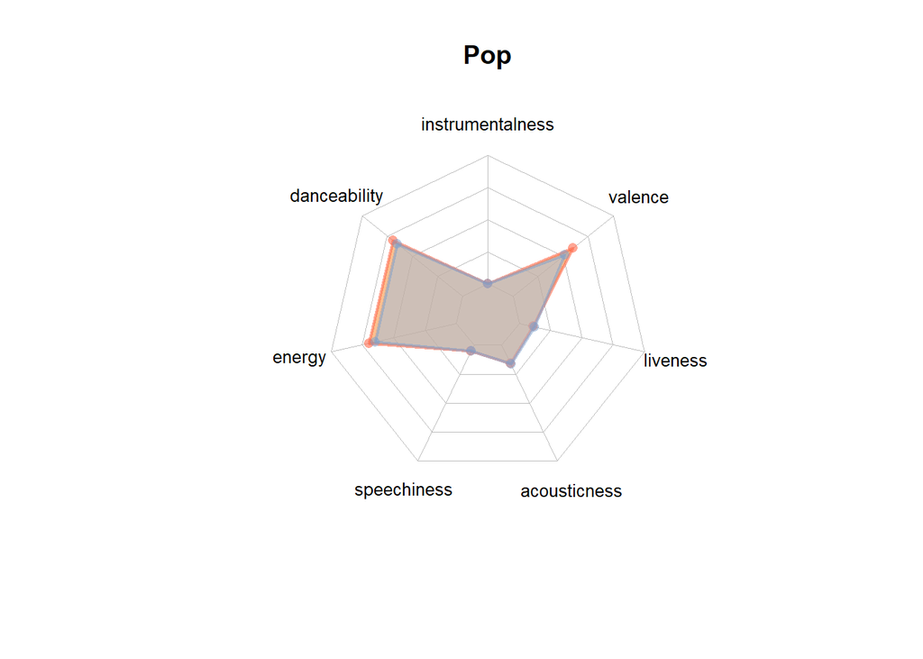

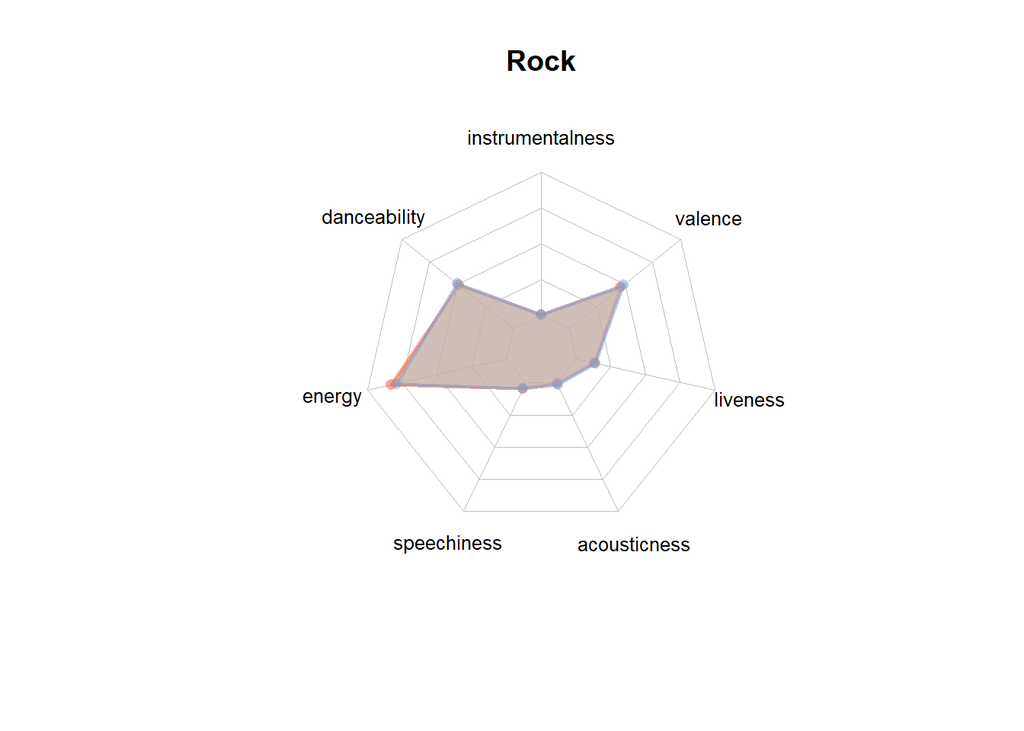

```r
by_genre %>% group_map(~radar_plot_tb_popular(.x, .y))
```

To further organize our code, I created a function that takes a percentile probablity and calculate the stats.

```r
calculate_data <- function(tb_sub, tb_filtered, prob) {
  filtered <- c()
  sub <- c()

  feature_names_wo_popularity <- feature_names[1:7]
  for (i in 1:length(feature_names_wo_popularity)){
    filtered_col_numeric <- as.numeric(as.character(unlist(tb_filtered[,feature_names[i]])))
    sub_col_numeric <- as.numeric(as.character(unlist(tb_sub[,feature_names[i]])))
    filtered[i] <- quantile(filtered_col_numeric, probs=prob)
    sub[i] <- quantile(sub_col_numeric, probs=prob)
  }

  return(list("filtered"=filtered, "sub"=sub))
}
```

Then, I refactored the `build_data_tb()` function to include a probability argument and calculate data for that percentile for the group table and a subset of popular songs in the group.

```r
build_data_tb_with_measure <- function(tb, popularity_threshold, prob){
  tb_sub <- tb[,feature_names]
  tb_filtered <- filter(tb_sub, Popularity >= popularity_threshold)
  stats <- calculate_data(tb_sub, tb_filtered, prob)

  feature_names_wo_popularity <- feature_names[1:7]

  range_max <- rep(1, length(feature_names_wo_popularity))
  range_min <- rep(0, length(feature_names_wo_popularity))

  data_tb <- data.frame(matrix(ncol = length(feature_names_wo_popularity), nrow = 0))
  data_tb[1,] <- stats$filtered
  data_tb[2,] <- stats$sub

  colnames(data_tb) <- feature_names_wo_popularity
  rownames(data_tb) <- c("popualar songs", "all songs")

  data_tb <- rbind(range_max , range_min , data_tb)

  return(data_tb)
}
```

With the data table built from `build_data_tb_with_measure()`, the plotting function can cleanly get the data needed for plotting and also with the flexibility of specifying various percentiles. Note that if we want to check out maximums, we just need to set `prob = 1`.

```r
radar_plot_tb_popular_with_measure <- function(tb, group_by_column, prob){
  tb_genre <- group_by_column$Genre

  data_tb <- build_data_tb_with_measure(tb, popularity_threshold, prob)

  colors_border=c( scales::alpha("#FF6A4C", 0.6), scales::alpha("#779ecc", 0.5) )
  colors_in=c( scales::alpha("#F99244", 0.6), scales::alpha("#9fc0de", 0.5) )

  type_title <- ""
  if (prob == 1) {
    type_title <- "Max"
  } else {
    type_title <- paste("Quantile: ", as.character(prob))
  }

  radarchart( data_tb    , axistype=0,
    #custom polygon
    pcol=colors_border, pfcol=colors_in , plwd=2 , plty=1,
    #custom the grid
    cglcol="grey", cglty=1, axislabcol="black", cglwd=0.8, caxislabels=seq(0,1,0.1),
    #custom labels
    vlcex=0.8, title=paste(tb_genre, type_title)
    )
}
```

Now we can start experimenting with different quantiles.

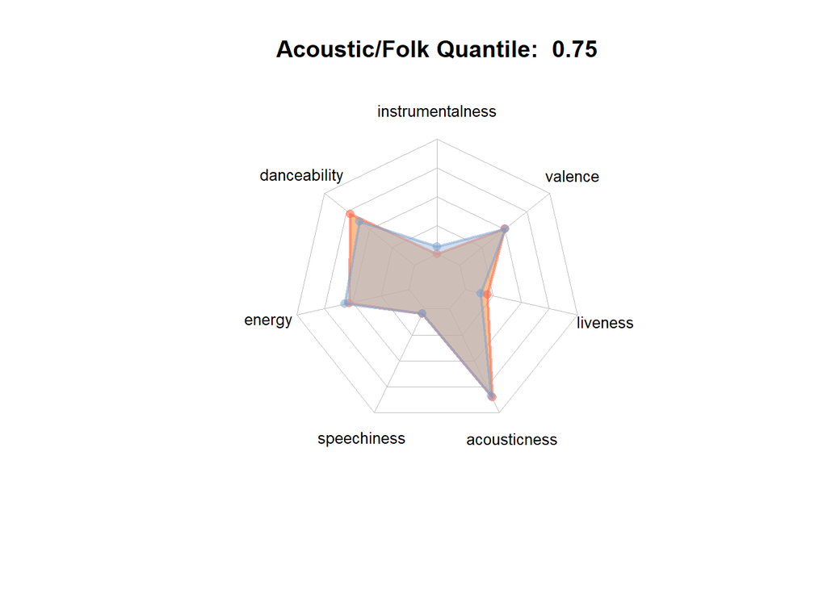

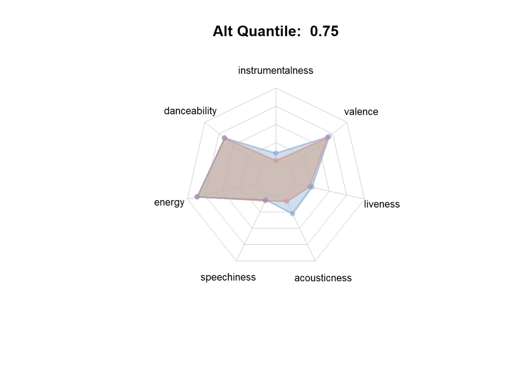

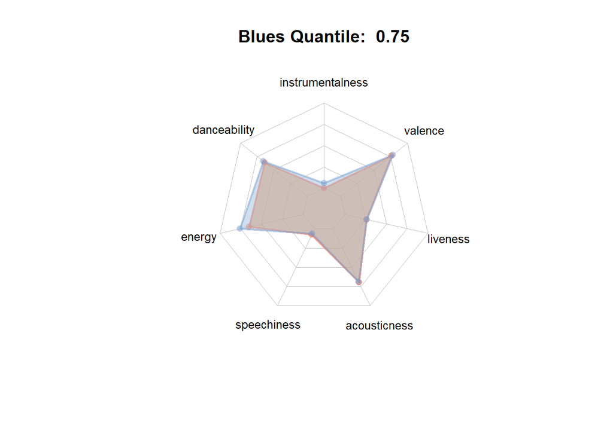

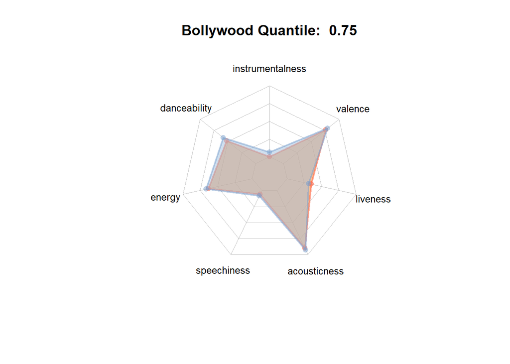

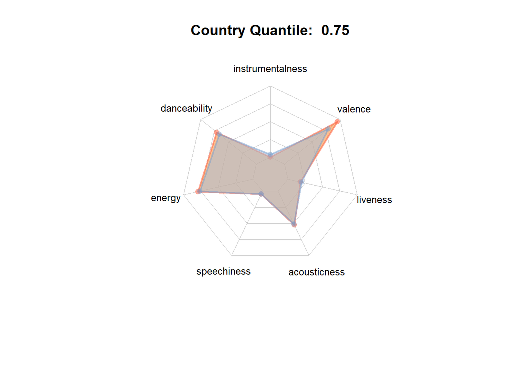

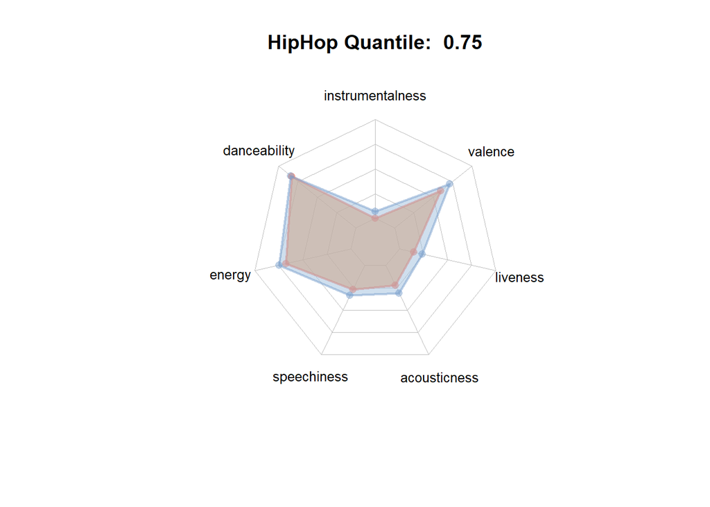

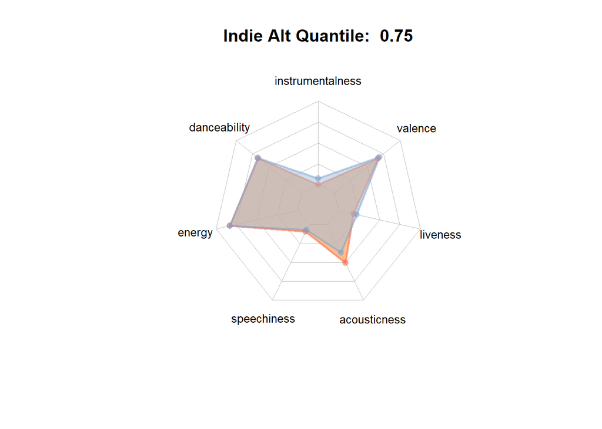

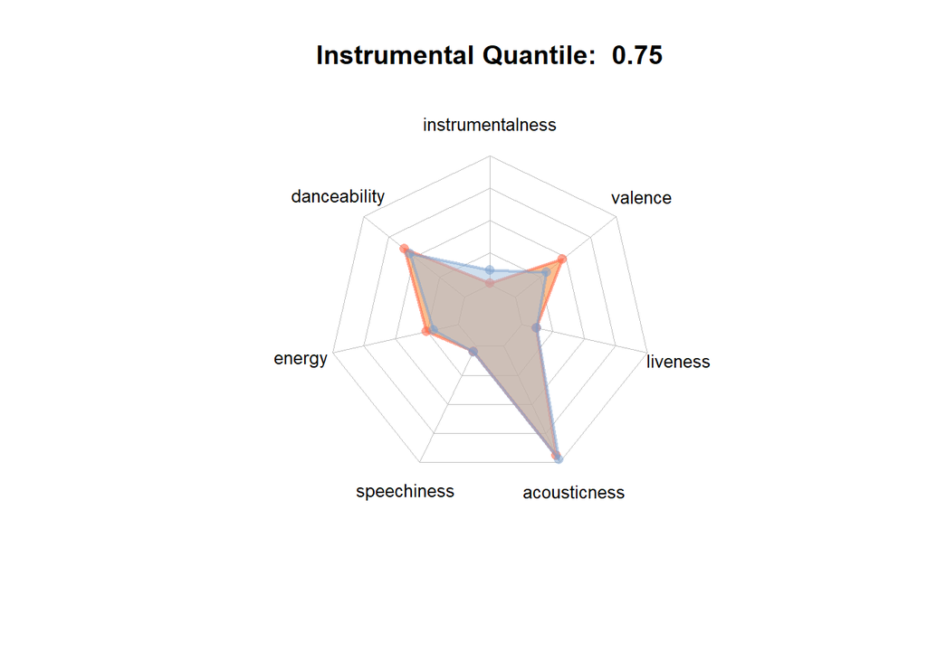

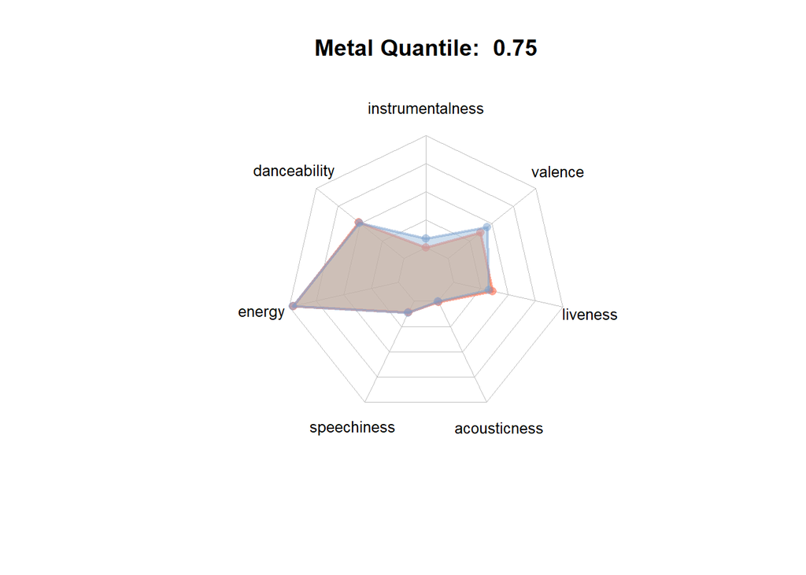

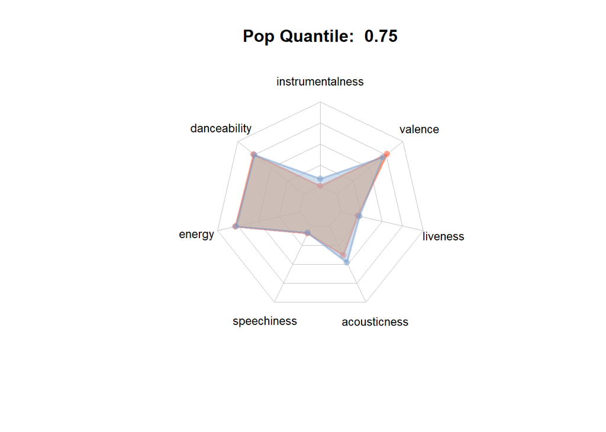

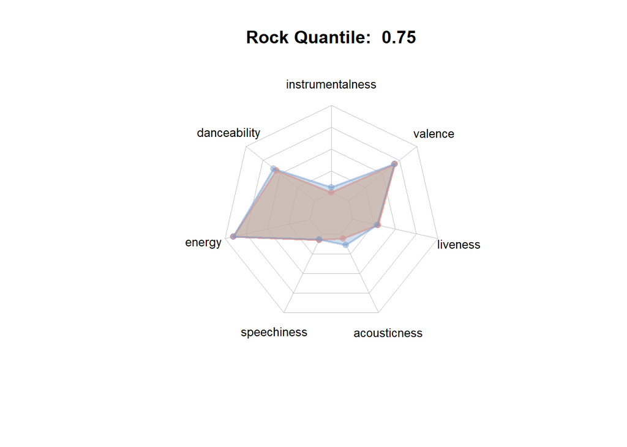

```r
by_genre %>% group_map(~radar_plot_tb_popular_with_measure(.x, .y, prob=0.75))
```

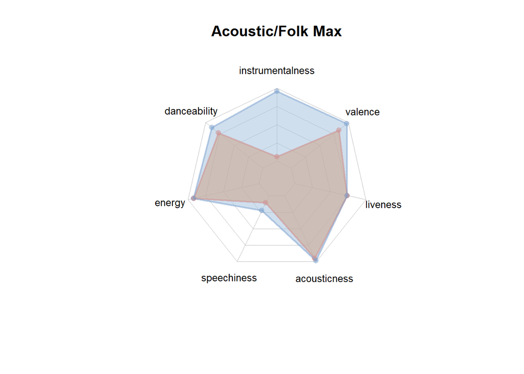

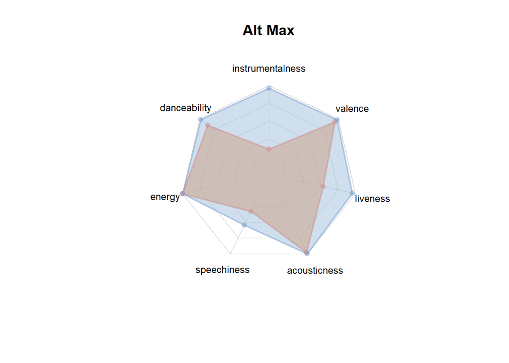

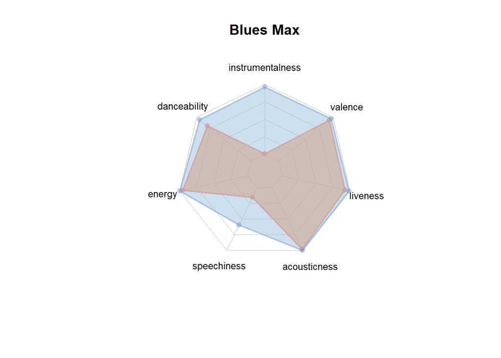

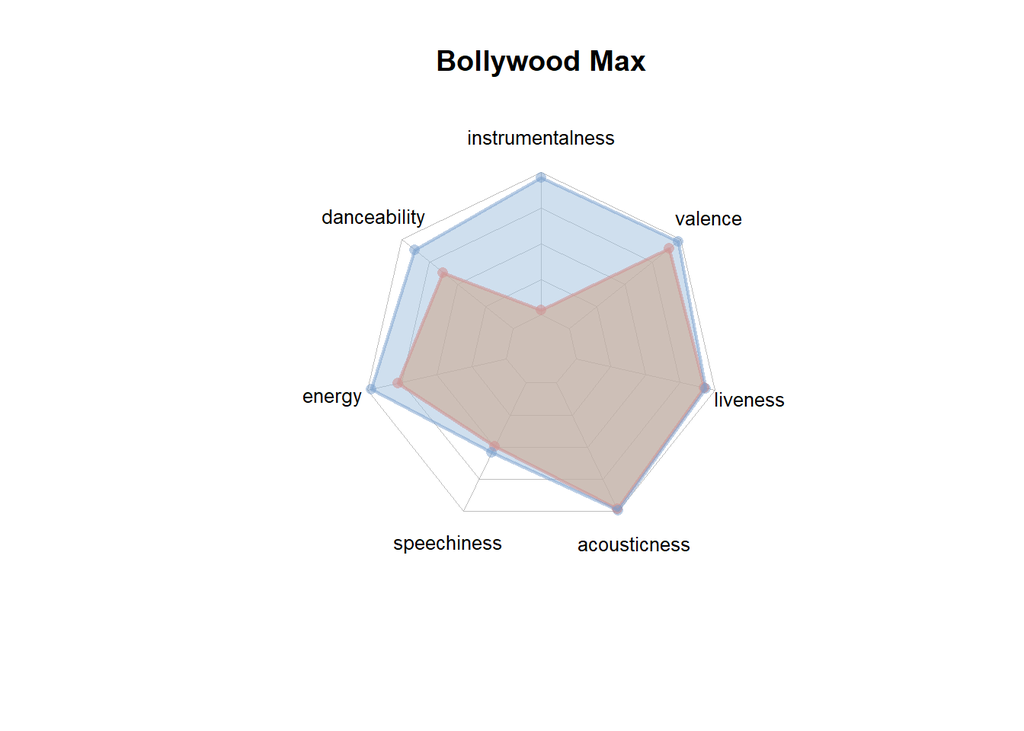

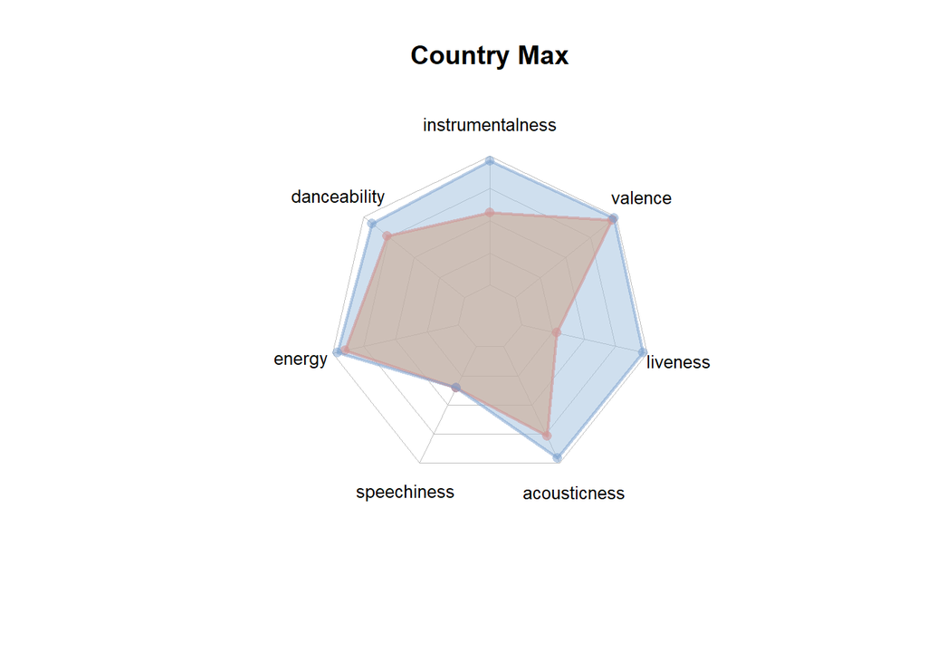

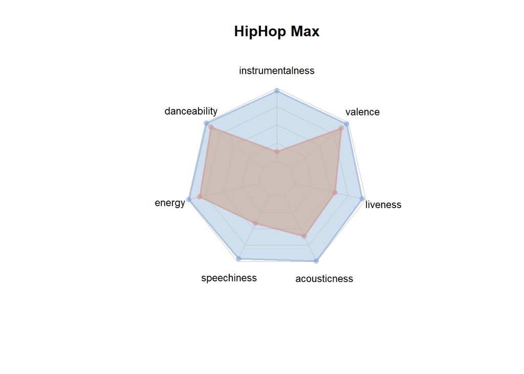

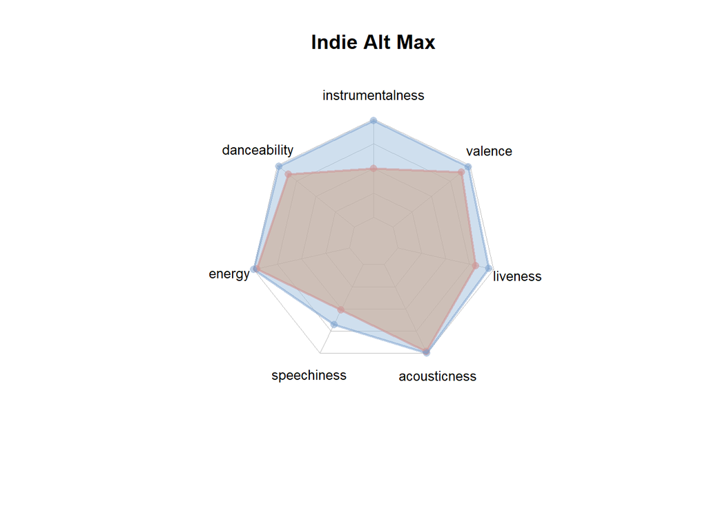

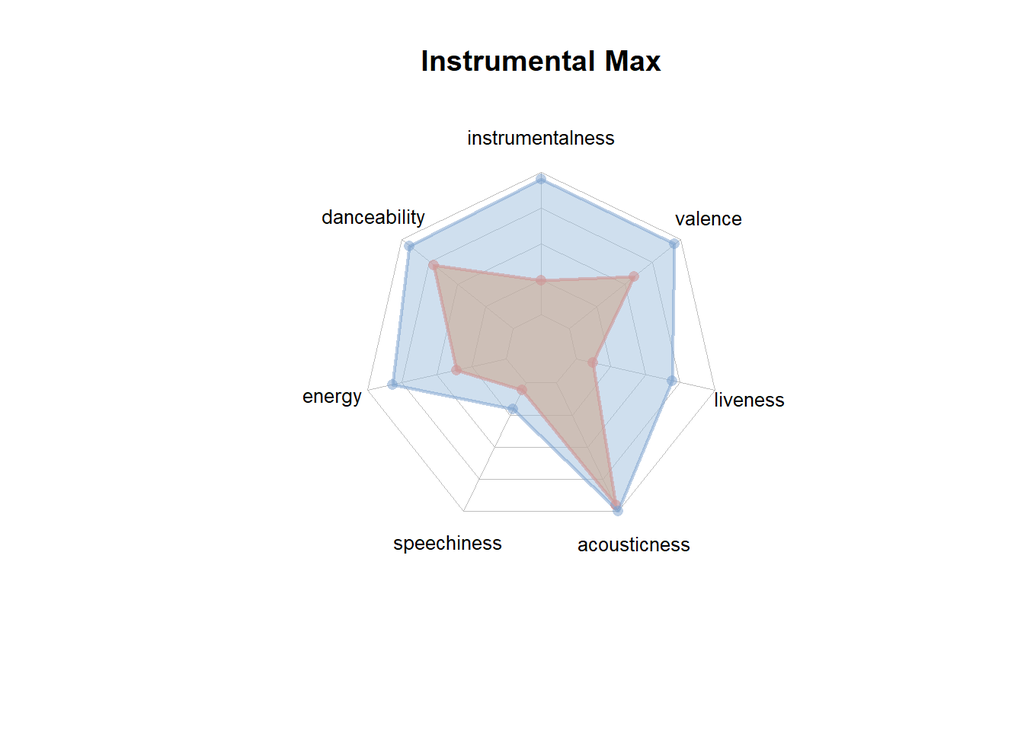

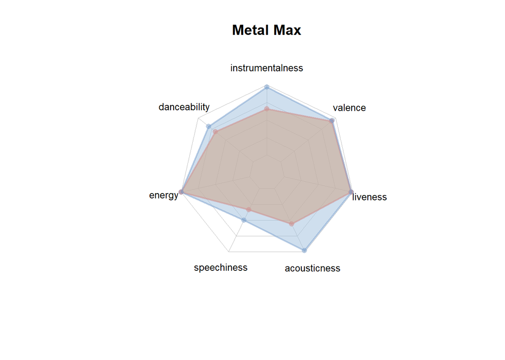

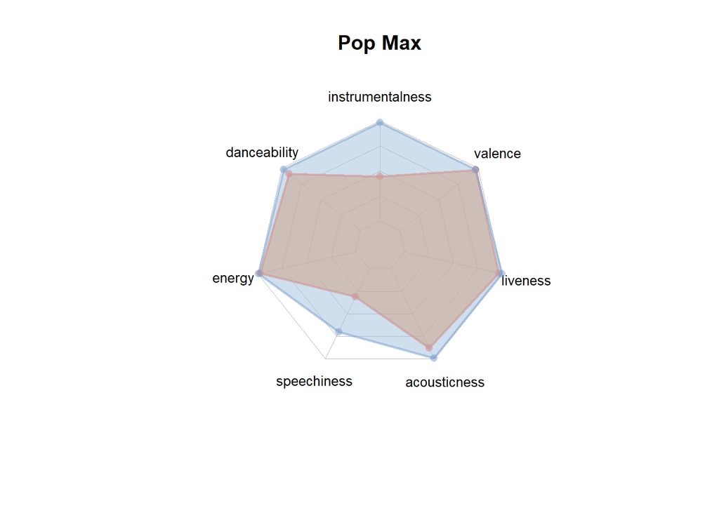

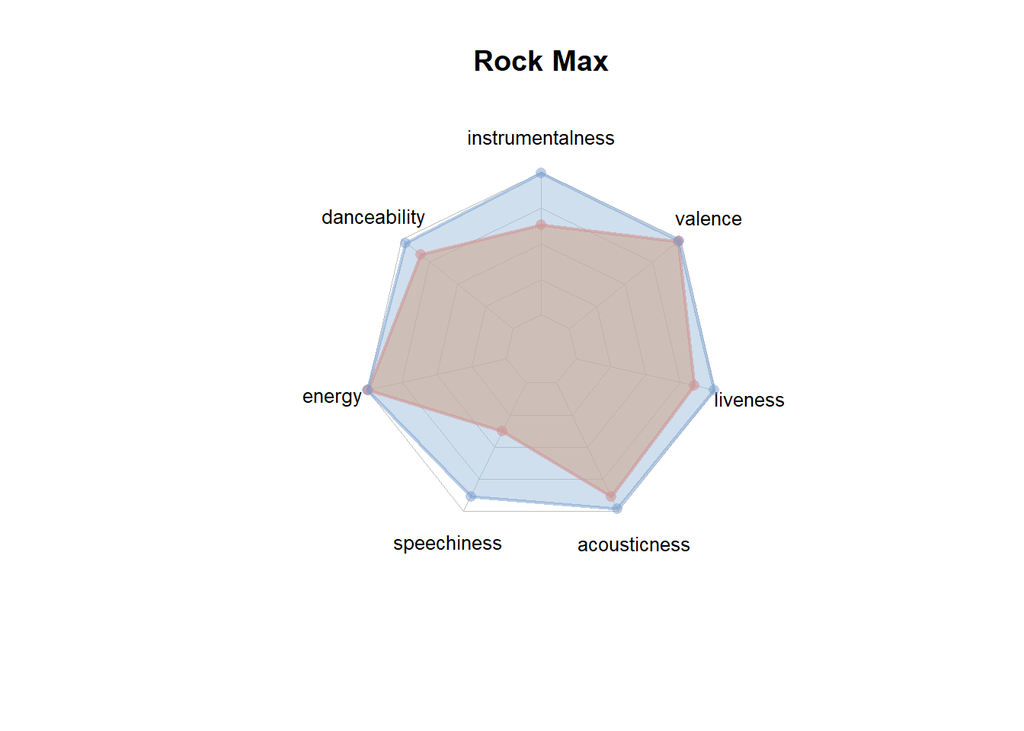

```r
by_genre %>% group_map(~radar_plot_tb_popular_with_measure(.x, .y, prob=1))
```

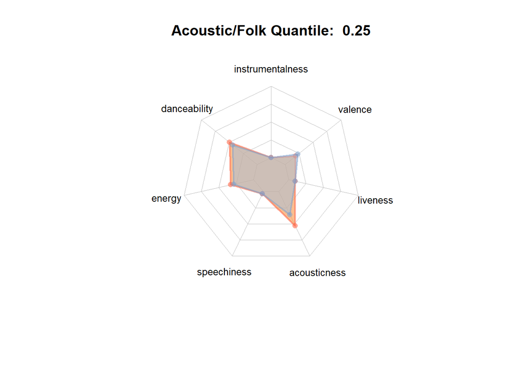

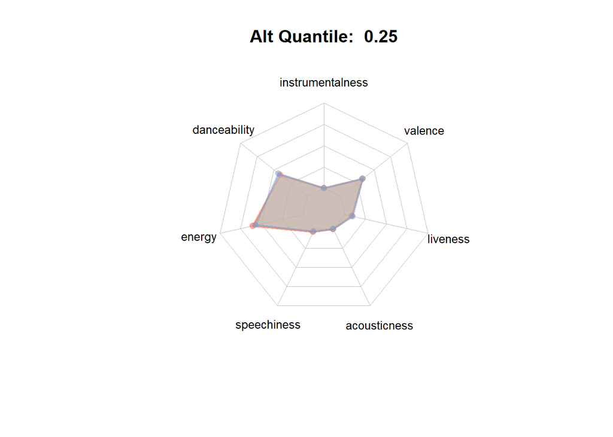

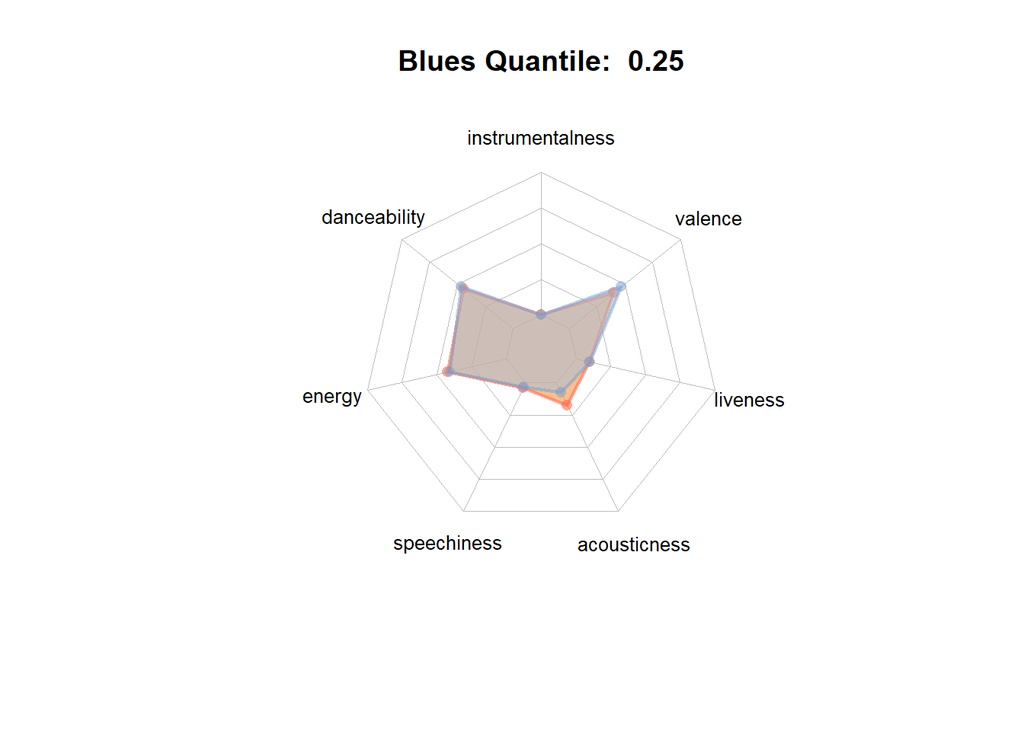

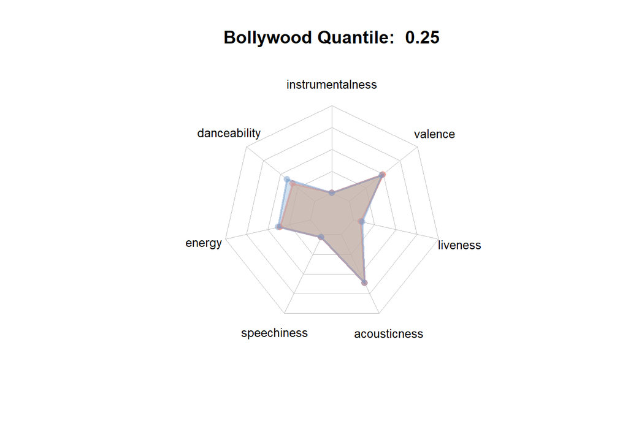

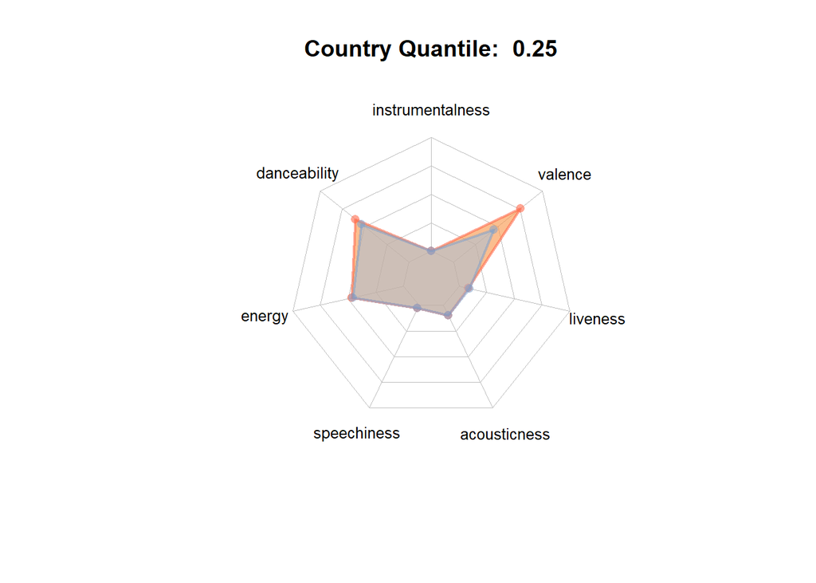

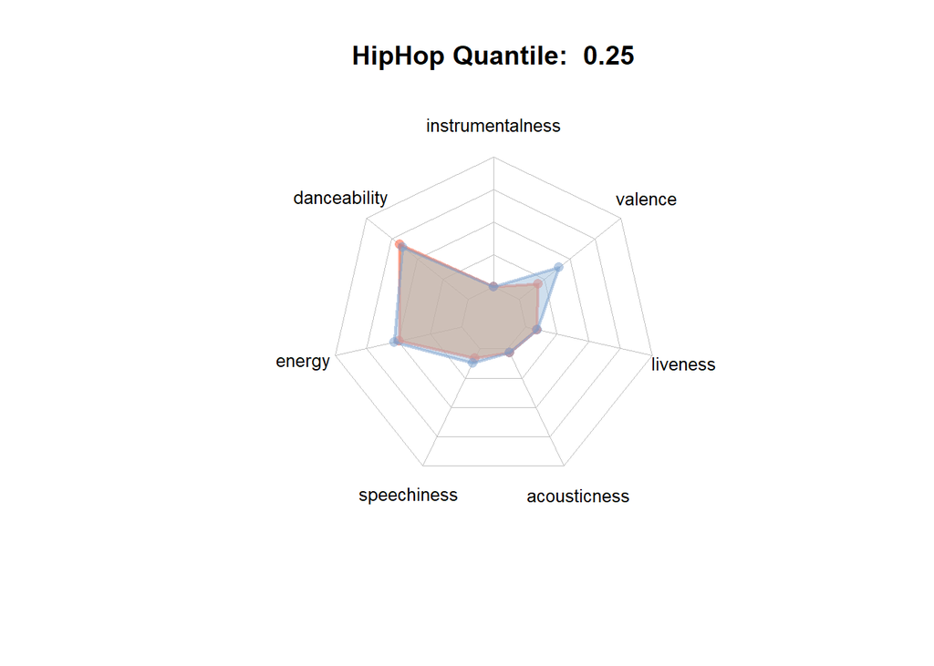

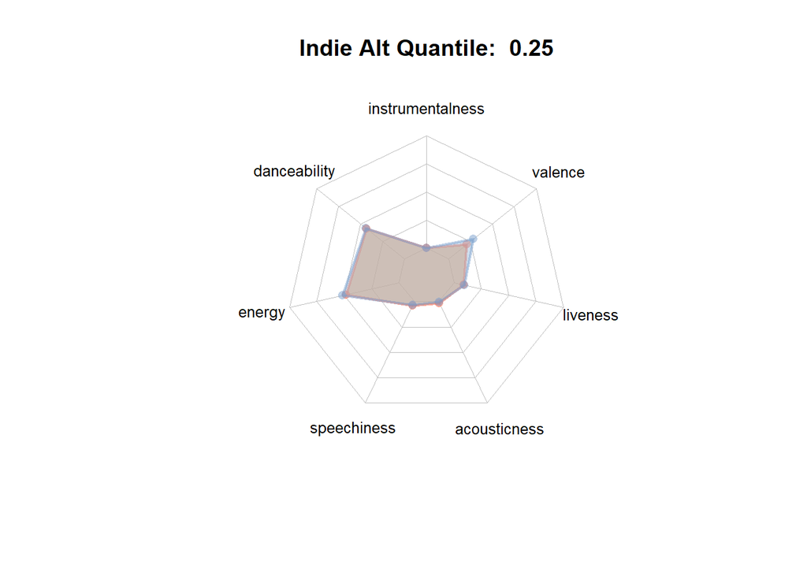

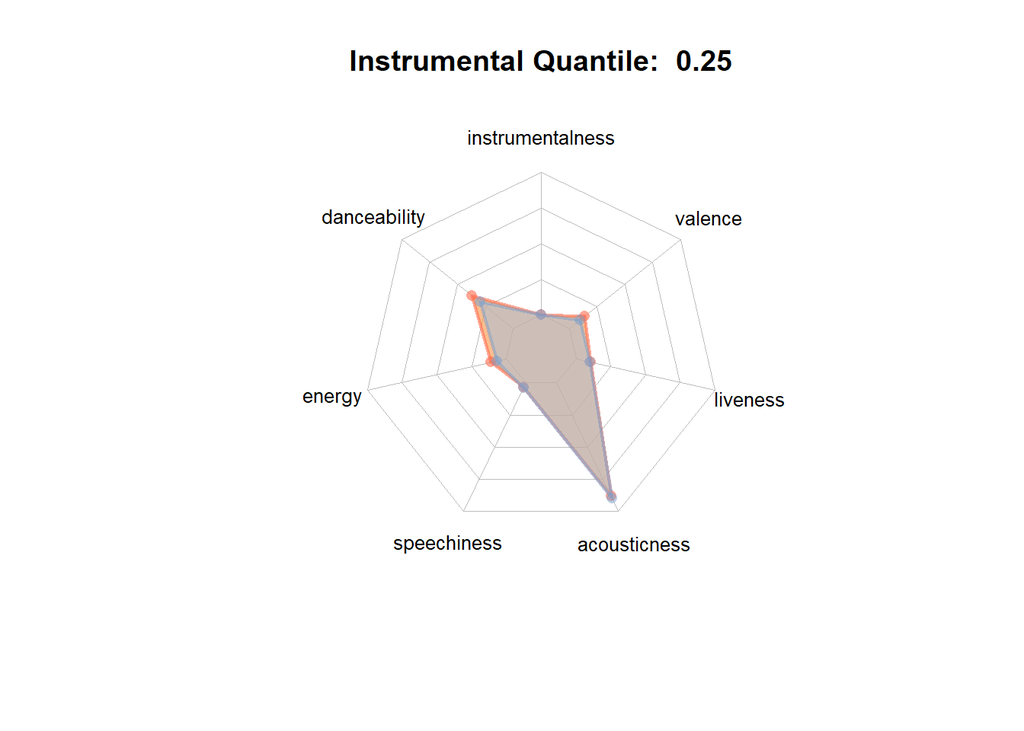

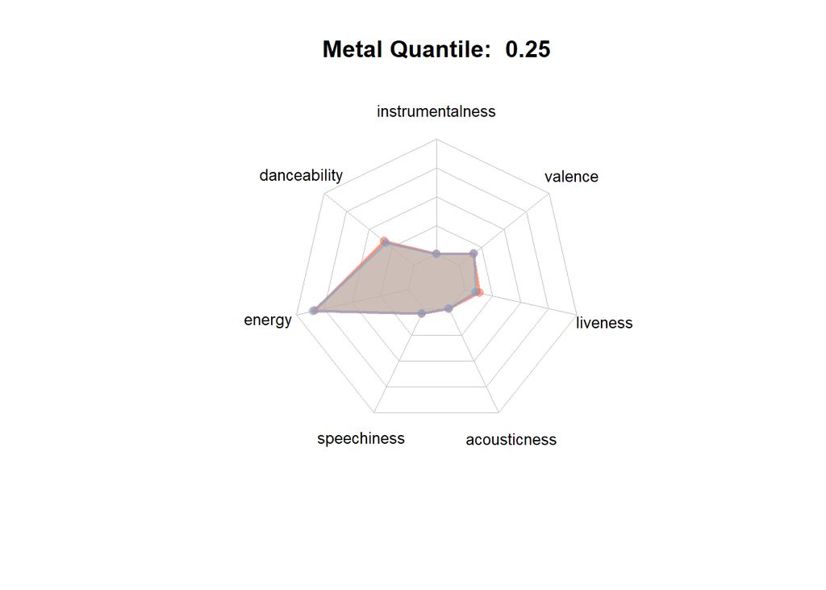

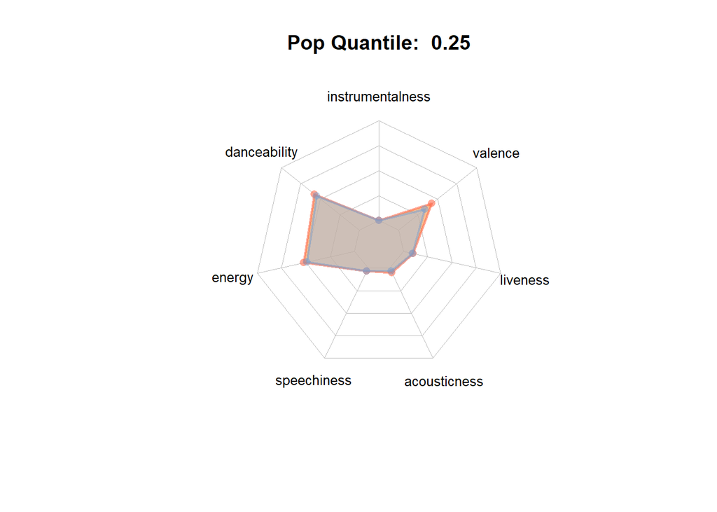

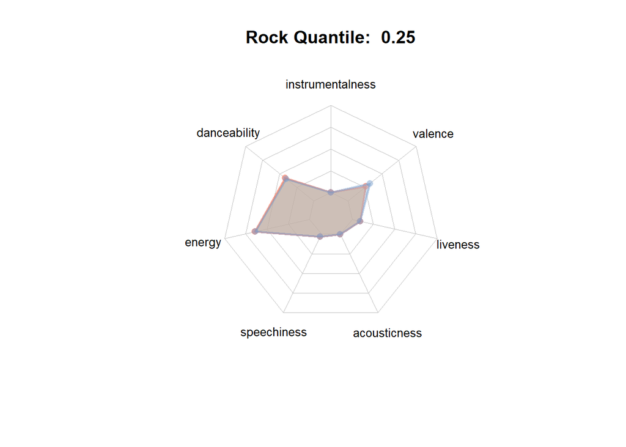

```r
by_genre %>% group_map(~radar_plot_tb_popular_with_measure(.x, .y, prob=0.25))
```